# LAB 9 : Mohit Manglani

### Write a NumPy program to create a 3X4 array and iterate over it.

```python
import numpy as np

array = np.arange(1, 13).reshape(3, 4)
print("3x4 Array:")
print(array)

print("\nIterating over the array:")
for row in array:
    print(row)
```

```
3x4 Array:
[[ 1  2  3  4]
 [ 5  6  7  8]
 [ 9 10 11 12]]

Iterating over the array:
[1 2 3 4]
[5 6 7 8]
[ 9 10 11 12]
```

### Write a NumPy program to create a 3x4 matrix filled with values from 10 to 21.

```python
matrix = np.arange(10, 22).reshape(3, 4)
print("3x4 Matrix:")
print(matrix)
```

```
3x4 Matrix:
[[10 11 12 13]
 [14 15 16 17]
 [18 19 20 21]]
```

### Write a NumPy program to create a 10x10 matrix, in which the elements on the borders will be equal to 1, and inside 0

```python
matrix = np.ones((10, 10) ,dtype=int)
matrix[1:-1, 1:-1] = 0
print("10x10 Matrix with borders 1 and inside 0:")
print(matrix)
```

```
10x10 Matrix with borders 1 and inside 0:
[[1 1 1 1 1 1 1 1 1 1]
 [1 0 0 0 0 0 0 0 0 1]
 [1 0 0 0 0 0 0 0 0 1]
 [1 0 0 0 0 0 0 0 0 1]
 [1 0 0 0 0 0 0 0 0 1]
 [1 0 0 0 0 0 0 0 0 1]
 [1 0 0 0 0 0 0 0 0 1]
 [1 0 0 0 0 0 0 0 0 1]
 [1 0 0 0 0 0 0 0 0 1]
 [1 1 1 1 1 1 1 1 1 1]]
```

### Write a Python function that takes two 2D arrays as input and returns their matrix product using NumPy

```python
def matrix_product(arr1, arr2):
    return np.dot(arr1, arr2)

# Example usage:
arr1 = np.array([[1, 2], [3, 4]])
arr2 = np.array([[5, 6], [7, 8]])
print("Matrix product:")
print(matrix_product(arr1, arr2))
```

```
Matrix product:
[[19 22]
 [43 50]]
```

### Write a Python function that takes a 1D NumPy array as input and returns a new array with all even numbers squared and odd numbers unchanged

```python
def process_array(arr):
    return np.where(arr % 2 == 0, arr**2, arr)

# Example usage:
arr = np.array([1, 2, 3, 4, 5, 6])
print("Processed array:")
print(process_array(arr))
```

```
Processed array:
[ 1  4  3 16  5 36]
```

### Write a NumPy program to compute the sum of all elements, the sum of each column and the sum of each row in a given array

```python
array = np.array([[1, 2, 3], [4, 5, 6], [7, 8, 9]])
print("Sum of all elements:", np.sum(array))
print("Sum of each column:", np.sum(array, axis=0))
print("Sum of each row:", np.sum(array, axis=1))
```

```
Sum of all elements: 45
Sum of each column: [12 15 18]
Sum of each row: [ 6 15 24]
```

### Write a NumPy program to add a vector to each row of a given matrix.

```python
matrix = np.array([[1, 2, 3], [4, 5, 6], [7, 8, 9]])
vector = np.array([1, 0, -1])
print("Matrix after adding vector to each row:")
print(matrix + vector)
```

```
Matrix after adding vector to each row:
[[2 2 2]
 [5 5 5]
 [8 8 8]]
```

### Consider a given series:

#### QTR1 50000

#### QTR2 65890

#### QTR3 56780

#### QTR4 89000

#### QTR5 77900

### Write a program in Python Pandas to create and display the series.

```python
import pandas as pd

data = [50000, 65890, 56780, 89000, 77900]
index = ['QTR1', 'QTR2', 'QTR3', 'QTR4', 'QTR5']
series = pd.Series(data, index=index)
print("Pandas Series:")
print(series)
```

```
Pandas Series:
QTR1    50000
QTR2    65890
QTR3    56780
QTR4    89000
QTR5    77900
dtype: int64
```

### Write a Pandas program to add, subtract, multiple and divide two Pandas Series

```python
series1 = pd.Series([1, 2, 3, 4])
series2 = pd.Series([10, 20, 30, 40])

print("Addition:")
print(series1 + series2)

print("Subtraction:")
print(series1 - series2)

print("Multiplication:")
print(series1 * series2)

print("Division:")
print(series1 / series2)
```

```
Addition:
0    11
1    22
2    33
3    44
dtype: int64
Subtraction:
0    -9
1   -18
2   -27
3   -36
dtype: int64
Multiplication:
0     10
1     40
2     90
3    160
dtype: int64
Division:
0    0.1
1    0.1
2    0.1
3    0.1
dtype: float64
```

### Write a Pandas program to convert given series into a dataframe with its index as another column on the dataframe

```python
df = series.reset_index()
df.columns = ['Quarter', 'Values']
print("DataFrame:")
print(df)
```

```
DataFrame:
  Quarter  Values
0    QTR1   50000
1    QTR2   65890
2    QTR3   56780
3    QTR4   89000
4    QTR5   77900
```

### Write a Pandas program to iterate over rows in a DataFrame

```python
data = {'A': [1, 2, 3], 'B': [4, 5, 6]}
df = pd.DataFrame(data)

print("Iterating over rows:")
for index, row in df.iterrows():
    print(f"Index {index}: {row.to_dict()}")
```

```
Iterating over rows:
Index 0: {'A': 1, 'B': 4}
Index 1: {'A': 2, 'B': 5}
Index 2: {'A': 3, 'B': 6}
```

### Write a Pandas program to rename columns of a given DataFrame

```python
df = df.rename(columns={'A': 'Column1', 'B': 'Column2'})
print("Renamed DataFrame:")
print(df)
```

```
Renamed DataFrame:
   Column1  Column2
0        1        4
1        2        5
2        3        6
```

### Write a Pandas program to add one row in an existing DataFrame

```python
new_row = pd.DataFrame({'Column1': [10], 'Column2': [20]})
df = pd.concat([df, new_row], ignore_index=True)
print("DataFrame after adding a row:")
print(df)
```

```
DataFrame after adding a row:
   Column1  Column2
0        1        4
1        2        5
2        3        6
3       10       20
```

### Write a Pandas program to write a DataFrame to CSV file using tab separator.

```python
df.to_csv('output.csv', sep='\t', index=False)
print("DataFrame written to 'output.csv' with tab separator.")
```

```
DataFrame written to 'output.csv' with tab separator.
```

### output of the above code is

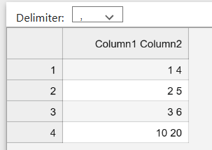

### Write a Pandas program to find the row for where the value of a given column is maximum

```python
data = {'Values': [10, 20, 30, 40, 50]}
df = pd.DataFrame(data)
max_row = df[df['Values'] == df['Values'].max()]
print("Row with maximum value:")
print(max_row)
```

```
Row with maximum value:
   Values
4      50
```